# 4) Predictions, Recommendations and Conclusions

```python
import numpy as np
import pandas as pd
import matplotlib.pyplot as plt
import seaborn as sns
from sklearn.linear_model import LinearRegression
import matplotlib.dates as mdates

from statsmodels.tsa.ar_model import AutoReg
import datetime as dt

import warnings
warnings.filterwarnings('ignore')
```

## Predicting the number of vaccines that will administered

### Getting all the datasets

```python
# importing the prediction data
df_pred = pd.read_csv('../clean_data/predictions.csv')

# lets rename columns for easy use
df_pred.rename(columns={"Unnamed: 0": "date" , "7dayrollingavg_newlyconfirmed":"7D_roll_pred", 'County':'county'},inplace = True)

# lets reset the index to county
df_pred.set_index('county', inplace= True)

# import data wise california vaccine allocation

df_vacc_alloc = pd.read_csv('../clean_data/vaccine_population.csv')
df_vacc_alloc = df_vacc_alloc[df_vacc_alloc['jurisdiction'] == 'California']
df_vacc_alloc.drop(columns=['2019_population','hhs_region','total_first_allocation' ], inplace = True)

# importing vaccination adminstration  data
df_vacc_admin = pd.read_csv('../clean_data/scrapped_ca_vaccine_ext_feb.csv')
df_vacc_admin.drop(columns=['Unnamed: 5', 'Unnamed: 4'], inplace = True)


# importing county population data
df_county_pop = pd.read_csv('../clean_data/cases_with_mask_use.csv')

# get county and population information only
df_county_pop = pd.DataFrame(df_county_pop.groupby(by = 'county')['population'].max())
```

## EDA on county population

```python
df_county_pop.head()
```

| county | population |
| --- | --- |
| Alameda | 1671329 |
| Alpine | 1129 |
| Amador | 39752 |
| Butte | 219186 |
| Calaveras | 45905 |

```python
# Lets create a column that gives the county population ratio to California pop
# of county population to total california population. We will use this for dosage distribution
df_county_pop['ratio_county_pop'] = (df_county_pop['population']/ df_county_pop['population'].sum())
df_county_pop.reset_index(inplace= True)
```

## EDA on prediction data

```python
# lets look at the data
df_pred.head()
# '2021-02-14'
```

| county | date | 7D_roll_pred |
| --- | --- | --- |
| Alameda | 2020-09-27 | 5.572982 |
| Alameda | 2020-09-28 | 5.402031 |
| Alameda | 2020-09-29 | 5.419126 |
| Alameda | 2020-09-30 | 4.726777 |
| Alameda | 2020-10-01 | 4.367782 |

## EDA on vaccination Adminstration data

```python
df_vacc_admin
```

|  | state | date | total_doses_distributed | total_doses_administered |
| --- | --- | --- | --- | --- |
| 0 | California | 2021-01-16 | 3548575 | 1072959 |
| 1 | California | 2021-01-17 | 3548575 | 1072959 |
| 2 | California | 2021-01-18 | 3548575 | 1072959 |
| 3 | California | 2021-01-19 | 3548575 | 1072959 |
| 4 | California | 2021-01-20 | 3548575 | 1072959 |
| 5 | California | 2021-01-21 | 4169450 | 1532329 |
| 6 | California | 2021-01-22 | 4379500 | 1633875 |
| 7 | California | 2021-01-23 | 4714625 | 1803679 |
| 8 | California | 2021-01-24 | 4906525 | 2008220 |
| 9 | California | 2021-01-25 | 4906525 | 2199908 |
| 10 | California | 2021-01-26 | 4906525 | 2330633 |
| 11 | California | 2021-01-27 | 5393400 | 1982075 |
| 12 | California | 2021-01-28 | 5852930 | 2150952 |
| 13 | California | 2021-01-29 | 6303428 | 2316510 |
| 14 | California | 2021-01-30 | 6759551 | 2484135 |
| 15 | California | 2021-01-31 | 7216562 | 2652087 |
| 16 | California | 2021-02-01 | 7216562 | 2652087 |
| 17 | California | 2021-02-02 | 7216562 | 2652087 |
| 18 | California | 2021-02-03 | 7216562 | 2652087 |
| 19 | California | 2021-02-04 | 9132955 | 3356361 |
| 20 | California | 2021-02-05 | 9609340 | 3531432 |
| 21 | California | 2021-02-06 | 10090802 | 3708370 |
| 22 | California | 2021-02-07 | 10584774 | 3889904 |
| 23 | California | 2021-02-08 | 11059712 | 4064444 |
| 24 | California | 2021-02-09 | 11059712 | 4064444 |
| 25 | California | 2021-02-10 | 11059712 | 4064444 |
| 26 | California | 2021-02-11 | 11059712 | 4064444 |
| 27 | California | 2021-02-12 | 11059712 | 4064444 |
| 28 | California | 2021-02-13 | 13444487 | 4940849 |
| 29 | California | 2021-02-14 | 13928842 | 5118849 |
| 30 | California | 2021-02-15 | 14415203 | 5297587 |
| 31 | California | 2021-02-16 | 14415203 | 5297587 |
| 32 | California | 2021-02-17 | 14415203 | 5297587 |
| 33 | California | 2021-02-18 | 15772652 | 5796450 |
| 34 | California | 2021-02-19 | 16269284 | 5978962 |
| 35 | California | 2021-02-20 | 16743195 | 6153124 |
| 36 | California | 2021-02-21 | 17239971 | 6335689 |
| 37 | California | 2021-02-22 | 17239971 | 6335689 |
| 38 | California | 2021-02-23 | 17239971 | 6335689 |
| 39 | California | 2021-02-24 | 17239971 | 6335689 |
| 40 | California | 2021-02-25 | 19154912 | 7039430 |
| 41 | California | 2021-02-26 | 19615662 | 7208756 |
| 42 | California | 2021-02-27 | 20082209 | 7380212 |
| 43 | California | 2021-02-28 | 20544096 | 7549955 |

```python
# lets look at the data
df_vacc_admin = df_vacc_admin[df_vacc_admin['state']=='California'][['state' , 'date' ,'total_doses_distributed','total_doses_administered']]
df_vacc_admin["date"]= pd.to_datetime(df_vacc_admin["date"])
```

```python
pd.set_option('display.max_rows', 100)
df_vacc_admin.head()
```

|  | state | date | total_doses_distributed | total_doses_administered |
| --- | --- | --- | --- | --- |
| 0 | California | 2021-01-16 | 3548575 | 1072959 |
| 1 | California | 2021-01-17 | 3548575 | 1072959 |
| 2 | California | 2021-01-18 | 3548575 | 1072959 |
| 3 | California | 2021-01-19 | 3548575 | 1072959 |
| 4 | California | 2021-01-20 | 3548575 | 1072959 |

#### Two steps to be added for this

#### Step 1: need to roll up the data for 7 day ahead. i.e 2021-01-16 should be summed up for 6 days ahead.

#### Step 2: need to split up the data for each county by date.

### Step 1: need to roll up the data for 7 day ahead. i.e 2021-01-16 should be summed up for 6 days ahead.

```python
df_vacc_admin.head()
```

|  | state | date | total_doses_distributed | total_doses_administered |
| --- | --- | --- | --- | --- |
| 0 | California | 2021-01-16 | 3548575 | 1072959 |
| 1 | California | 2021-01-17 | 3548575 | 1072959 |
| 2 | California | 2021-01-18 | 3548575 | 1072959 |
| 3 | California | 2021-01-19 | 3548575 | 1072959 |
| 4 | California | 2021-01-20 | 3548575 | 1072959 |

```python
df_vacc_admin.head()
```

|  | state | date | total_doses_distributed | total_doses_administered |
| --- | --- | --- | --- | --- |
| 0 | California | 2021-01-16 | 3548575 | 1072959 |
| 1 | California | 2021-01-17 | 3548575 | 1072959 |
| 2 | California | 2021-01-18 | 3548575 | 1072959 |
| 3 | California | 2021-01-19 | 3548575 | 1072959 |
| 4 | California | 2021-01-20 | 3548575 | 1072959 |

```python
# lets create new column that is the cumulative 7 days for doses adminstered and doses distributed

df_vacc_admin['doses_dist_7roll'] = 0
df_vacc_admin['doses_admin_7roll'] = 0
for i in range(0,30):
    df_vacc_admin['doses_dist_7roll'][i]= df_vacc_admin['total_doses_distributed'][i+6]- df_vacc_admin['total_doses_distributed'][i]
    df_vacc_admin['doses_admin_7roll'][i]= df_vacc_admin['total_doses_administered'][i+6]- df_vacc_admin['total_doses_administered'][i]
```

```python
# lets remove the dates we dont need i.e any records beyond 2021-02-14
df_vacc_admin = df_vacc_admin[df_vacc_admin['date'] <= '2021-02-14']
```

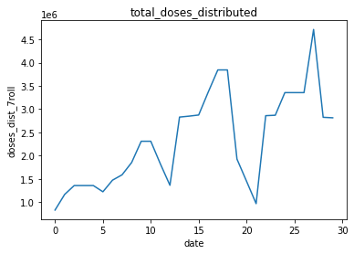

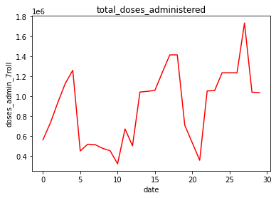

```python
# The adjusted close accounts for stock splits, so that is what we should graph
plt.plot(df_vacc_admin.index, df_vacc_admin['doses_dist_7roll'])
plt.title('total_doses_distributed')
plt.ylabel('doses_dist_7roll');
plt.xlabel('date');
plt.show()

# The adjusted close accounts for stock splits, so that is what we should graph
plt.plot(df_vacc_admin.index, df_vacc_admin['doses_admin_7roll'] , 'r')
plt.title('total_doses_administered')
plt.ylabel('doses_admin_7roll');
plt.xlabel('date');
plt.show()
```

### Generating recommendations for how many vaccines each county should get

```python
df_county_pop.head()
```

|  | county | population | ratio_county_pop |
| --- | --- | --- | --- |
| 0 | Alameda | 1671329 | 0.042299 |
| 1 | Alpine | 1129 | 0.000029 |
| 2 | Amador | 39752 | 0.001006 |
| 3 | Butte | 219186 | 0.005547 |
| 4 | Calaveras | 45905 | 0.001162 |

```python
df_vacc_admin.head()
```

|  | state | date | total_doses_distributed | total_doses_administered | doses_dist_7roll | doses_admin_7roll |
| --- | --- | --- | --- | --- | --- | --- |
| 0 | California | 2021-01-16 | 3548575 | 1072959 | 830925 | 560916 |
| 1 | California | 2021-01-17 | 3548575 | 1072959 | 1166050 | 730720 |
| 2 | California | 2021-01-18 | 3548575 | 1072959 | 1357950 | 935261 |
| 3 | California | 2021-01-19 | 3548575 | 1072959 | 1357950 | 1126949 |
| 4 | California | 2021-01-20 | 3548575 | 1072959 | 1357950 | 1257674 |

```python
# lets do a cross join and merge the data sets for county and county population ratio.
# this will help us to divide the doses admininstered and doses distributed 7 days cumulative by county

# since we have to do a cross join on two data frames that donot have a Key, lets create a key that is same.
df_county_pop['joinkey'] = 0
df_vacc_admin['joinkey'] = 0

# lets merge the vaccine and county population data together
df_county_vacc_dist_admin_7Droll = pd.merge(df_vacc_admin, df_county_pop, on="joinkey" , how="outer")

# selecting only the columns we need
df_county_vacc_dist_admin_7Droll = df_county_vacc_dist_admin_7Droll[['county' ,'date','doses_dist_7roll','doses_admin_7roll', 'ratio_county_pop']]

# rounding the county distribution and adminstration numbers
df_county_vacc_dist_admin_7Droll['doses_dist_7roll_county'] = round(df_county_vacc_dist_admin_7Droll['doses_dist_7roll'] * df_county_vacc_dist_admin_7Droll['ratio_county_pop'])
df_county_vacc_dist_admin_7Droll['doses_admin_7roll_county'] = round(df_county_vacc_dist_admin_7Droll['doses_admin_7roll'] * df_county_vacc_dist_admin_7Droll['ratio_county_pop'])

# selecting only the columns we needed
df_county_vacc_dist_admin_7Droll=df_county_vacc_dist_admin_7Droll[['county', 'date', 'doses_dist_7roll_county' , 'doses_admin_7roll_county' ]]
```

```python
# final data set for Vaccine Adminstraion and Distribution by County and Date
df_county_vacc_dist_admin_7Droll.head()
```

|  | county | date | doses_dist_7roll_county | doses_admin_7roll_county |
| --- | --- | --- | --- | --- |
| 0 | Alameda | 2021-01-16 | 35147.0 | 23726.0 |
| 1 | Alpine | 2021-01-16 | 24.0 | 16.0 |
| 2 | Amador | 2021-01-16 | 836.0 | 564.0 |
| 3 | Butte | 2021-01-16 | 4609.0 | 3112.0 |
| 4 | Calaveras | 2021-01-16 | 965.0 | 652.0 |

### Merge data sets together

#### create a dataframe that has County, Date, Prediction, County population, vaccine allocation

```python
# lets add population to predictions
df_county_vacc_pred_7Droll  =  pd.merge(df_pred ,df_county_pop, on ='county' , how = 'left' )

# since the 7 day rolling average was based off 100K , we need to calculate actual number of 7 day new patients
df_county_vacc_pred_7Droll['7D_roll_pred_tot'] = np.round((df_county_vacc_pred_7Droll['7D_roll_pred'] * df_county_vacc_pred_7Droll['population'])/ 100_000)

#df_county_vacc_pred_7Droll['7D_roll_pred_tot'] = np.round((df_county_vacc_pred_7Droll['7D_roll_pred'] * 100_000))



# lets look at merged data
df_county_vacc_pred_7Droll = df_county_vacc_pred_7Droll[['county', 'date' ,'7D_roll_pred_tot' ]]
```

### Append the 'county to population ratio' to merged data set.

```python
df_county_vacc_pred_7Droll["date"]= pd.to_datetime(df_county_vacc_pred_7Droll["date"])
```

```python
df_county_resource = pd.merge(df_county_vacc_pred_7Droll, df_county_vacc_dist_admin_7Droll, on=['county' , 'date'], how="inner")
```

```python
df_county_resource.head()
```

|  | county | date | 7D_roll_pred_tot | doses_dist_7roll_county | doses_admin_7roll_county |
| --- | --- | --- | --- | --- | --- |
| 0 | Alameda | 2021-01-16 | 923.0 | 35147.0 | 23726.0 |
| 1 | Alameda | 2021-01-17 | 895.0 | 49323.0 | 30909.0 |
| 2 | Alameda | 2021-01-18 | 856.0 | 57440.0 | 39561.0 |
| 3 | Alameda | 2021-01-19 | 827.0 | 57440.0 | 47669.0 |
| 4 | Alameda | 2021-01-20 | 745.0 | 57440.0 | 53198.0 |

### Calculate the DELTA the difference between predicted new patients and vaccines available

```python
df_county_resource.head()
```

|  | county | date | 7D_roll_pred_tot | doses_dist_7roll_county | doses_admin_7roll_county |
| --- | --- | --- | --- | --- | --- |
| 0 | Alameda | 2021-01-16 | 923.0 | 35147.0 | 23726.0 |
| 1 | Alameda | 2021-01-17 | 895.0 | 49323.0 | 30909.0 |
| 2 | Alameda | 2021-01-18 | 856.0 | 57440.0 | 39561.0 |
| 3 | Alameda | 2021-01-19 | 827.0 | 57440.0 | 47669.0 |
| 4 | Alameda | 2021-01-20 | 745.0 | 57440.0 | 53198.0 |

```python
df_county_resource['delta'] = df_county_resource['7D_roll_pred_tot'] - ( df_county_resource['doses_dist_7roll_county'])
```

```python
df_county_resource[df_county_resource['date'] == '2021-02-07']
```

|  | county | date | 7D_roll_pred_tot | doses_dist_7roll_county | doses_admin_7roll_county | delta |
| --- | --- | --- | --- | --- | --- | --- |
| 22 | Alameda | 2021-02-07 | 411.0 | 120963.0 | 44454.0 | -120552.0 |
| 52 | Amador | 2021-02-07 | 16.0 | 2877.0 | 1057.0 | -2861.0 |
| 82 | Butte | 2021-02-07 | 67.0 | 15864.0 | 5830.0 | -15797.0 |
| 112 | Calaveras | 2021-02-07 | 17.0 | 3322.0 | 1221.0 | -3305.0 |
| 142 | Colusa | 2021-02-07 | 11.0 | 1559.0 | 573.0 | -1548.0 |
| 172 | Contra Costa | 2021-02-07 | 299.0 | 83487.0 | 30681.0 | -83188.0 |
| 202 | Del Norte | 2021-02-07 | 2.0 | 2013.0 | 740.0 | -2011.0 |
| 232 | El Dorado | 2021-02-07 | 92.0 | 13957.0 | 5129.0 | -13865.0 |
| 262 | Fresno | 2021-02-07 | 280.0 | 72310.0 | 26574.0 | -72030.0 |
| 292 | Glenn | 2021-02-07 | 5.0 | 2055.0 | 755.0 | -2050.0 |
| 322 | Humboldt | 2021-02-07 | 17.0 | 9811.0 | 3606.0 | -9794.0 |
| 352 | Imperial | 2021-02-07 | 98.0 | 13116.0 | 4820.0 | -13018.0 |
| 382 | Inyo | 2021-02-07 | 2.0 | 1306.0 | 480.0 | -1304.0 |
| 412 | Kern | 2021-02-07 | 361.0 | 65152.0 | 23944.0 | -64791.0 |
| 442 | Kings | 2021-02-07 | 130.0 | 11069.0 | 4068.0 | -10939.0 |
| 472 | Lake | 2021-02-07 | 4.0 | 4660.0 | 1713.0 | -4656.0 |
| 502 | Lassen | 2021-02-07 | 56.0 | 2213.0 | 813.0 | -2157.0 |
| 532 | Los Angeles | 2021-02-07 | 6084.0 | 726584.0 | 267020.0 | -720500.0 |
| 562 | Madera | 2021-02-07 | 60.0 | 11387.0 | 4185.0 | -11327.0 |
| 592 | Marin | 2021-02-07 | 16.0 | 18733.0 | 6884.0 | -18717.0 |
| 622 | Mariposa | 2021-02-07 | 4.0 | 1245.0 | 458.0 | -1241.0 |
| 652 | Mendocino | 2021-02-07 | 7.0 | 6278.0 | 2307.0 | -6271.0 |
| 682 | Merced | 2021-02-07 | 127.0 | 20097.0 | 7386.0 | -19970.0 |
| 712 | Modoc | 2021-02-07 | 3.0 | 640.0 | 235.0 | -637.0 |
| 742 | Mono | 2021-02-07 | 16.0 | 1045.0 | 384.0 | -1029.0 |
| 772 | Monterey | 2021-02-07 | 228.0 | 31415.0 | 11545.0 | -31187.0 |
| 802 | Napa | 2021-02-07 | 34.0 | 9969.0 | 3664.0 | -9935.0 |
| 832 | Nevada | 2021-02-07 | 53.0 | 7220.0 | 2653.0 | -7167.0 |
| 862 | Orange | 2021-02-07 | 1219.0 | 229842.0 | 84467.0 | -228623.0 |
| 892 | Placer | 2021-02-07 | 156.0 | 28829.0 | 10595.0 | -28673.0 |
| 922 | Plumas | 2021-02-07 | 3.0 | 1361.0 | 500.0 | -1358.0 |
| 952 | Riverside | 2021-02-07 | 799.0 | 178807.0 | 65712.0 | -178008.0 |
| 982 | Sacramento | 2021-02-07 | 692.0 | 112331.0 | 41282.0 | -111639.0 |
| 1012 | San Benito | 2021-02-07 | 18.0 | 4546.0 | 1671.0 | -4528.0 |
| 1042 | San Bernardino | 2021-02-07 | 1883.0 | 157785.0 | 57986.0 | -155902.0 |
| 1072 | San Diego | 2021-02-07 | 1432.0 | 241613.0 | 88793.0 | -240181.0 |
| 1102 | San Francisco | 2021-02-07 | 46.0 | 63802.0 | 23447.0 | -63756.0 |
| 1132 | San Joaquin | 2021-02-07 | 302.0 | 55161.0 | 20272.0 | -54859.0 |
| 1162 | San Luis Obispo | 2021-02-07 | 68.0 | 20490.0 | 7530.0 | -20422.0 |
| 1192 | San Mateo | 2021-02-07 | 55.0 | 55481.0 | 20389.0 | -55426.0 |
| 1222 | Santa Barbara | 2021-02-07 | 25.0 | 32316.0 | 11876.0 | -32291.0 |
| 1252 | Santa Clara | 2021-02-07 | 764.0 | 139529.0 | 51277.0 | -138765.0 |
| 1282 | Santa Cruz | 2021-02-07 | 22.0 | 19774.0 | 7267.0 | -19752.0 |
| 1312 | Shasta | 2021-02-07 | 112.0 | 13033.0 | 4790.0 | -12921.0 |
| 1342 | Siskiyou | 2021-02-07 | 13.0 | 3151.0 | 1158.0 | -3138.0 |
| 1372 | Solano | 2021-02-07 | 117.0 | 32398.0 | 11906.0 | -32281.0 |
| 1402 | Sonoma | 2021-02-07 | 76.0 | 35778.0 | 13148.0 | -35702.0 |
| 1432 | Stanislaus | 2021-02-07 | 251.0 | 39854.0 | 14646.0 | -39603.0 |
| 1462 | Sutter | 2021-02-07 | 22.0 | 7018.0 | 2579.0 | -6996.0 |
| 1492 | Tehama | 2021-02-07 | 30.0 | 4710.0 | 1731.0 | -4680.0 |
| 1522 | Trinity | 2021-02-07 | 3.0 | 889.0 | 327.0 | -886.0 |
| 1552 | Tulare | 2021-02-07 | 76.0 | 33741.0 | 12400.0 | -33665.0 |
| 1582 | Tuolumne | 2021-02-07 | 33.0 | 3943.0 | 1449.0 | -3910.0 |
| 1612 | Ventura | 2021-02-07 | 127.0 | 61230.0 | 22502.0 | -61103.0 |
| 1642 | Yolo | 2021-02-07 | 89.0 | 15959.0 | 5865.0 | -15870.0 |
| 1672 | Yuba | 2021-02-07 | 48.0 | 5694.0 | 2092.0 | -5646.0 |

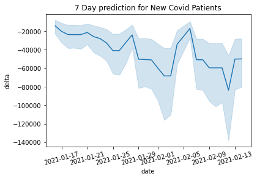

```python
import pandas as pd
import matplotlib.pyplot as plt

import seaborn as sns

sns.lineplot(x="date", y="delta", data=df_county_resource)
plt.xticks(rotation=15)
plt.title('7 Day prediction for New Covid Patients')
plt.show()
```

```python
# export the data
df_county_resource[df_county_resource['date'] == '2021-02-07'].to_csv('../clean_data/California_2021_02_07.csv', index=False)
```

## Conclusion

The primary findings from our study are as follows:

(1.) With 2.8MM vaccines allocated to California over next 22 weeks ( till July 2021), no county within California should have a shortfall for vaccinating everyone.

(2.) There is uncertainity and external factors that impact the findings from this study. These include (but are not restricted to) Goverment decisions, cadence of vaccine distribution and adminstration, spread of new strain of virus, opening up of cities and suburbs, which may have impact on the spread of virus. A majority of these decisions are driven by goverment policy. All factors remaining the same, there results from the study can be implemented.

(4.) This study also raises the question of ethics around life saving resource allocation. Using data techniques to divert life saving technology brings up the consideration on making decision whose impact can be irreversible. Also, the disease may impact demographics like age, gender, race ( and other ethonographic parameters) differently which introduces complexity in the decision making.